# $k$-means Clustering

$k$-means is a simple iterative algorithm for linearly separable data. It is a partitioning method that divides the data into $k$ clusters.

We will use it to cluster the Old Faithful gazer data set.

```r
# Load the data
data("faithful")
head(faithful)
```

```
##   eruptions waiting
## 1     3.600      79
## 2     1.800      54
## 3     3.333      74
## 4     2.283      62
## 5     4.533      85
## 6     2.883      55
```

The data set contains two variables: `eruptions` and `waiting`. We will use these two variables to cluster the data.

## Perform $k$-means clustering

```r
cl2 <- kmeans(faithful, centers = 2)
table(cl2$cluster)
```

```
##
##   1   2
## 100 172
```

The object `cl2$cluster` contains the cluster assignments for each observation. The `table` function shows the number of observations in each cluster. Moreover, `cl2$centers` contains the cluster centers and `cl2$withinss` contains the within-cluster sums of squares.

```r
print(cl2$centers) # Cluster centers
```

```
##   eruptions  waiting
## 1   2.09433 54.75000
## 2   4.29793 80.28488
```

```r
print(cl2$withinss) # Within-cluster sums of squares
```

```
## [1] 3456.178 5445.591
```

```r
print(cl2$tot.withinss) # Total sum of squared distances = sum(cl2$withinss)
```

```
## [1] 8901.769
```

## Visualize the clusters

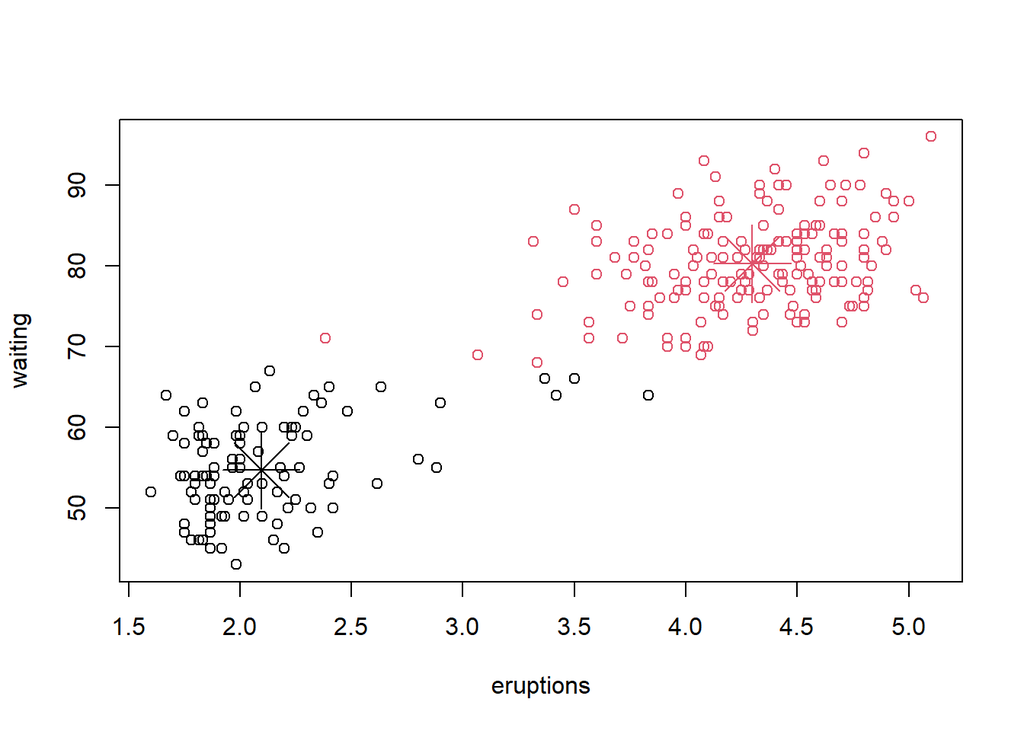

```r
plot(faithful, col = cl2$cluster)
points(cl2$centers, col = 1:2, pch = 8, cex = 5)
```

It is quite clear that there are 2 clusters, but how can we choose appropriate $k$ if we didn’t know it?

## Elbow method

Calculate $k$-means for different $k$ and plot $SS$ vs $k$.

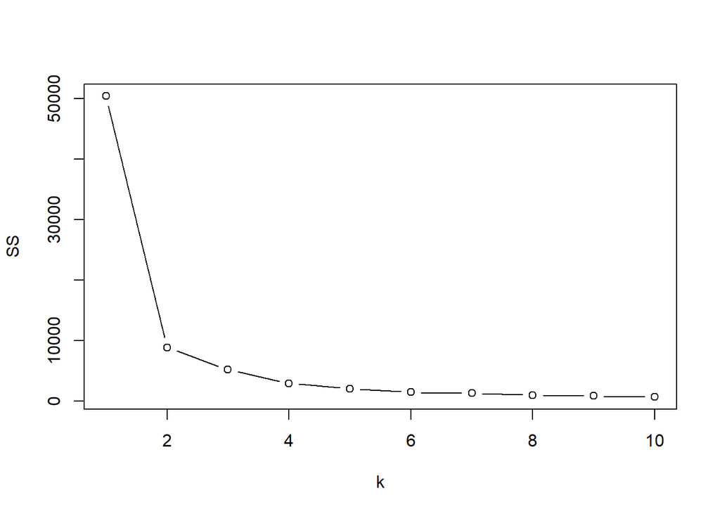

```r
SS <- rep(0, 10)
for (k in 1:10) {
  cl <- kmeans(faithful, centers = k)
  SS[k] <- cl$tot.withinss
}
plot(1:10, SS, type = "b", xlab = "k", ylab = "SS")
```

## Assessing the quality of the clusters

A good thing to do is to calculate the distance between cluster centers. And for each cluster calculate the average distance to its cluster center. If the average distance is smaller than the distance between cluster centers, then the clustering is compact and good.

We can define a function to do this.

```r
average_distance <- function(data, center) {
  n <- nrow(data)
  # add the center to the data as the last row
  # get the distance matrix and sum the last row
  total <- sum(as.matrix(dist(rbind(data, center)))[n + 1, ])
  return(total / n)
}

avg_dist_to_cluster_centers <- function(data, centers, clusters) {
  k <- nrow(centers)
  avg_dist <- rep(0, k)
  for (i in 1:k) {
    cluster_data <- data[which(clusters == i), ]
    avg_dist[i] <- average_distance(cluster_data, centers[i, ])
  }
  return(avg_dist)
}
```

We can now see how the clustering looks for $k = 2$. First we calculate the distance between cluster centers.

```r
dist(cl2$centers)
```

```
##          1
## 2 25.62979
```

And now the average distance to cluster centers.

```r
avg_dist_to_cluster_centers(faithful, cl2$centers, cl2$cluster)
```

```
## [1] 4.899079 4.556494
```

We can see that the clusters are vary compact.

Let’s try switching to $k = 3$ and see how the clustering looks.

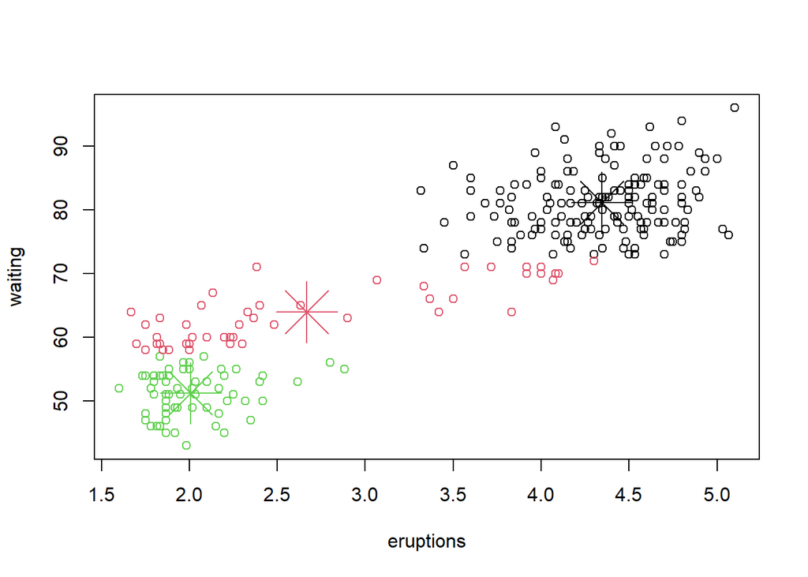

```r
cl3 <- kmeans(faithful, centers = 3)
plot(faithful, col = cl3$cluster)
points(cl3$centers, col = 1:3, pch = 8, cex = 5)
```

```r
print(dist(cl3$centers))
```

```
##          1        2
## 2 17.25247
## 3 29.94067 12.69574
```

```r
avg_dist_to_cluster_centers(faithful, cl3$centers, cl3$cluster)
```

```
## [1] 4.080581 4.073555 3.023563
```

## Silhouette width method

The silhouette width is a measure of how similar an object is to its own cluster compared to the second nearest cluster. The silhouette width ranges from -1 to 1. High value means that the clustering is well separated, values around 0 mean that the clusters are probably overlapping and negative numbers mean that the data point has probably been misclassified.

```r
library("cluster")

dist_mat <- dist(faithful)^2
silhouette_cl2 <- silhouette(cl2$cluster, dist_mat)

summary(silhouette_cl2)
```

```
## Silhouette of 272 units in 2 clusters from silhouette.default(x = cl2$cluster, dist = dist_mat) :
##  Cluster sizes and average silhouette widths:
##       100       172
## 0.8648855 0.8877335
## Individual silhouette widths:
##    Min. 1st Qu.  Median    Mean 3rd Qu.    Max.
##  0.1238  0.8915  0.9336  0.8793  0.9489  0.9556
```

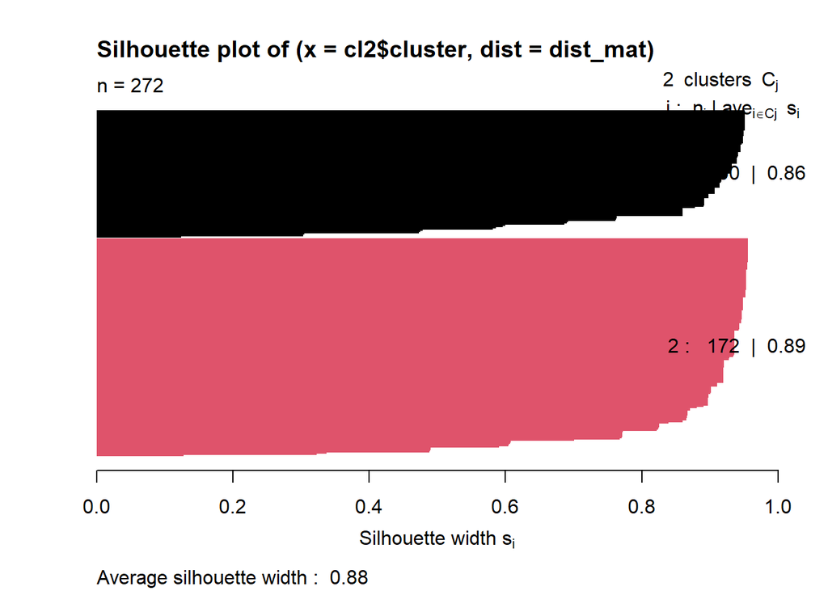

```r
plot(silhouette_cl2, col = 1:2, border = NA)
```

Here we constructed a distance matrix `dist_mat` that recorded the squared Euclidean distance between observations, which is the distance metric used in $k$-means clustering. This distance matrix was then used along with the cluster labels `cl2$cluster` to compute the silhouette width for all observations. Overall we see high average silhouette widths for both clusters (0.86 and 0.89) for Clusters 1 and 2 respectively. Plotting the silhouette width for all observations also shows that a majority of observations have high silhouette widths.

## Comparison with hierarchical clustering

```r
hcl <- cutree(hclust(dist(faithful)), 2)
icl <- kmeans(faithful, centers = 2)
table(hcl, icl$cluster)
```

```
##
## hcl   1   2
##   1  17 172
##   2  83   0
```

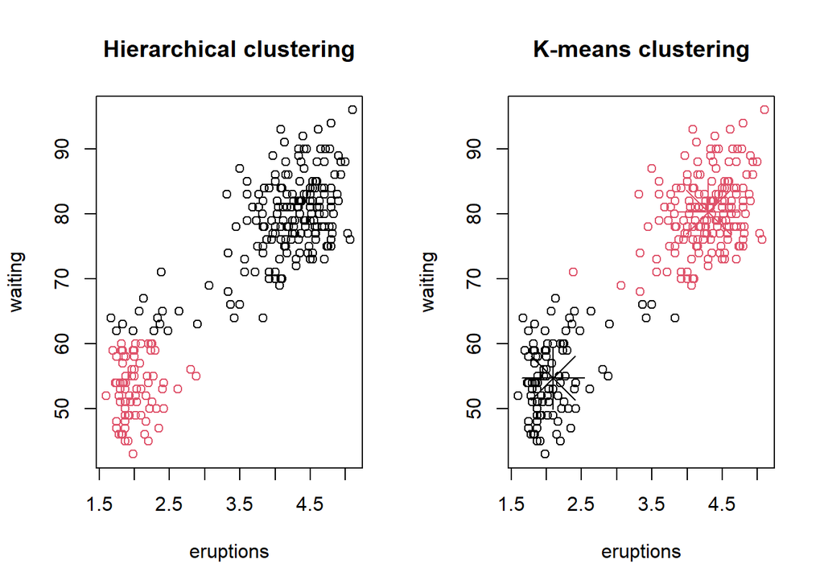

```r
par(mfrow = c(1, 2))
plot(faithful, col = hcl, main = "Hierarchical clustering")
plot(faithful, col = icl$cluster, main = "K-means clustering")
points(cl2$centers, col = 1:2, pch = 8, cex = 5)
```

The rand index of these two clusterings is:

```r
library(flexclust)
randIndex(hcl, icl$cluster)
```

```
##       ARI
## 0.7624052
```